# Optimal Treatment Analysis

## Outcome Variable

**Outcome Variable:** ever_stunted

## Predictor Variables

**Intervention Variable:** predfeed3

**Adjustment Set:**

- arm
- sex
- month
- brthmon
- W_mage
- meducyrs
- feducyrs
- hhwealth_quart
- hfoodsec
- W_mhtcm
- vagbrth
- W_gagebrth
- W_birthwt
- W_birthlen
- W_nrooms
- W_nchldlt5
- W_parity
- impfloor
- impsan
- safeh20
- delta_W_mage
- delta_meducyrs
- delta_feducyrs
- delta_hhwealth_quart
- delta_hfoodsec
- delta_W_mhtcm
- delta_vagbrth
- delta_W_gagebrth
- delta_W_birthwt
- delta_W_birthlen
- delta_W_nrooms
- delta_W_nchldlt5
- delta_W_parity
- delta_impfloor
- delta_impsan
- delta_safeh20

## Stratifying Variables

The analysis was stratified on these variable(s):

- agecat
- studyid
- country

## Data Summary

| agecat | studyid | country | predfeed3 | ever_stunted | n_cell | n |
| --- | --- | --- | --- | --- | --- | --- |
| 0-24 months (no birth st.) | ki0047075b-MAL-ED | BANGLADESH | 1 | 0 | 85 | 206 |
| 0-24 months (no birth st.) | ki0047075b-MAL-ED | BANGLADESH | 1 | 1 | 91 | 206 |
| 0-24 months (no birth st.) | ki0047075b-MAL-ED | BANGLADESH | 0 | 0 | 13 | 206 |
| 0-24 months (no birth st.) | ki0047075b-MAL-ED | BANGLADESH | 0 | 1 | 17 | 206 |
| 0-24 months (no birth st.) | ki0047075b-MAL-ED | BRAZIL | 1 | 0 | 93 | 202 |
| 0-24 months (no birth st.) | ki0047075b-MAL-ED | BRAZIL | 1 | 1 | 17 | 202 |
| 0-24 months (no birth st.) | ki0047075b-MAL-ED | BRAZIL | 0 | 0 | 81 | 202 |
| 0-24 months (no birth st.) | ki0047075b-MAL-ED | BRAZIL | 0 | 1 | 11 | 202 |
| 0-24 months (no birth st.) | ki0047075b-MAL-ED | INDIA | 1 | 0 | 61 | 200 |
| 0-24 months (no birth st.) | ki0047075b-MAL-ED | INDIA | 1 | 1 | 94 | 200 |
| 0-24 months (no birth st.) | ki0047075b-MAL-ED | INDIA | 0 | 0 | 33 | 200 |
| 0-24 months (no birth st.) | ki0047075b-MAL-ED | INDIA | 0 | 1 | 12 | 200 |
| 0-24 months (no birth st.) | ki0047075b-MAL-ED | NEPAL | 1 | 0 | 91 | 209 |
| 0-24 months (no birth st.) | ki0047075b-MAL-ED | NEPAL | 1 | 1 | 33 | 209 |
| 0-24 months (no birth st.) | ki0047075b-MAL-ED | NEPAL | 0 | 0 | 63 | 209 |
| 0-24 months (no birth st.) | ki0047075b-MAL-ED | NEPAL | 0 | 1 | 22 | 209 |
| 0-24 months (no birth st.) | ki0047075b-MAL-ED | PERU | 1 | 0 | 72 | 251 |
| 0-24 months (no birth st.) | ki0047075b-MAL-ED | PERU | 1 | 1 | 98 | 251 |
| 0-24 months (no birth st.) | ki0047075b-MAL-ED | PERU | 0 | 0 | 29 | 251 |
| 0-24 months (no birth st.) | ki0047075b-MAL-ED | PERU | 0 | 1 | 52 | 251 |
| 0-24 months (no birth st.) | ki0047075b-MAL-ED | SOUTH AFRICA | 1 | 0 | 37 | 246 |
| 0-24 months (no birth st.) | ki0047075b-MAL-ED | SOUTH AFRICA | 1 | 1 | 51 | 246 |
| 0-24 months (no birth st.) | ki0047075b-MAL-ED | SOUTH AFRICA | 0 | 0 | 77 | 246 |
| 0-24 months (no birth st.) | ki0047075b-MAL-ED | SOUTH AFRICA | 0 | 1 | 81 | 246 |
| 0-24 months (no birth st.) | ki0047075b-MAL-ED | TANZANIA, UNITED REPUBLIC OF | 1 | 0 | 17 | 211 |
| 0-24 months (no birth st.) | ki0047075b-MAL-ED | TANZANIA, UNITED REPUBLIC OF | 1 | 1 | 66 | 211 |
| 0-24 months (no birth st.) | ki0047075b-MAL-ED | TANZANIA, UNITED REPUBLIC OF | 0 | 0 | 19 | 211 |
| 0-24 months (no birth st.) | ki0047075b-MAL-ED | TANZANIA, UNITED REPUBLIC OF | 0 | 1 | 109 | 211 |
| 0-24 months (no birth st.) | ki1000109-EE | PAKISTAN | 1 | 0 | 30 | 248 |
| 0-24 months (no birth st.) | ki1000109-EE | PAKISTAN | 1 | 1 | 202 | 248 |

[output cut: 102 more lines]

The following strata were considered:

- agecat: 0-24 months (no birth st.), studyid: ki0047075b-MAL-ED, country: BANGLADESH
- agecat: 0-24 months (no birth st.), studyid: ki0047075b-MAL-ED, country: BRAZIL
- agecat: 0-24 months (no birth st.), studyid: ki0047075b-MAL-ED, country: INDIA
- agecat: 0-24 months (no birth st.), studyid: ki0047075b-MAL-ED, country: NEPAL
- agecat: 0-24 months (no birth st.), studyid: ki0047075b-MAL-ED, country: PERU
- agecat: 0-24 months (no birth st.), studyid: ki0047075b-MAL-ED, country: SOUTH AFRICA
- agecat: 0-24 months (no birth st.), studyid: ki0047075b-MAL-ED, country: TANZANIA, UNITED REPUBLIC OF
- agecat: 0-24 months (no birth st.), studyid: ki1000109-EE, country: PAKISTAN
- agecat: 0-24 months (no birth st.), studyid: ki1113344-GMS-Nepal, country: NEPAL
- agecat: 0-24 months (no birth st.), studyid: kiGH5241-JiVitA-3, country: BANGLADESH
- agecat: 0-24 months (no birth st.), studyid: kiGH5241-JiVitA-4, country: BANGLADESH
- agecat: 0-6 months (no birth st.), studyid: ki0047075b-MAL-ED, country: BANGLADESH
- agecat: 0-6 months (no birth st.), studyid: ki0047075b-MAL-ED, country: BRAZIL
- agecat: 0-6 months (no birth st.), studyid: ki0047075b-MAL-ED, country: INDIA
- agecat: 0-6 months (no birth st.), studyid: ki0047075b-MAL-ED, country: NEPAL
- agecat: 0-6 months (no birth st.), studyid: ki0047075b-MAL-ED, country: PERU
- agecat: 0-6 months (no birth st.), studyid: ki0047075b-MAL-ED, country: SOUTH AFRICA
- agecat: 0-6 months (no birth st.), studyid: ki0047075b-MAL-ED, country: TANZANIA, UNITED REPUBLIC OF
- agecat: 0-6 months (no birth st.), studyid: ki1000109-EE, country: PAKISTAN
- agecat: 0-6 months (no birth st.), studyid: ki1113344-GMS-Nepal, country: NEPAL
- agecat: 0-6 months (no birth st.), studyid: kiGH5241-JiVitA-3, country: BANGLADESH
- agecat: 0-6 months (no birth st.), studyid: kiGH5241-JiVitA-4, country: BANGLADESH
- agecat: 6-24 months, studyid: ki0047075b-MAL-ED, country: BANGLADESH
- agecat: 6-24 months, studyid: ki0047075b-MAL-ED, country: BRAZIL
- agecat: 6-24 months, studyid: ki0047075b-MAL-ED, country: INDIA
- agecat: 6-24 months, studyid: ki0047075b-MAL-ED, country: NEPAL
- agecat: 6-24 months, studyid: ki0047075b-MAL-ED, country: PERU
- agecat: 6-24 months, studyid: ki0047075b-MAL-ED, country: SOUTH AFRICA
- agecat: 6-24 months, studyid: ki0047075b-MAL-ED, country: TANZANIA, UNITED REPUBLIC OF
- agecat: 6-24 months, studyid: ki1000109-EE, country: PAKISTAN
- agecat: 6-24 months, studyid: ki1113344-GMS-Nepal, country: NEPAL
- agecat: 6-24 months, studyid: kiGH5241-JiVitA-3, country: BANGLADESH
- agecat: 6-24 months, studyid: kiGH5241-JiVitA-4, country: BANGLADESH

### Dropped Strata

Some strata were dropped due to rare outcomes:

- agecat: 0-24 months (no birth st.), studyid: ki1000109-EE, country: PAKISTAN
- agecat: 0-24 months (no birth st.), studyid: kiGH5241-JiVitA-4, country: BANGLADESH
- agecat: 0-6 months (no birth st.), studyid: kiGH5241-JiVitA-4, country: BANGLADESH
- agecat: 6-24 months, studyid: ki0047075b-MAL-ED, country: BRAZIL
- agecat: 6-24 months, studyid: ki1000109-EE, country: PAKISTAN
- agecat: 6-24 months, studyid: kiGH5241-JiVitA-4, country: BANGLADESH

## Methods Detail

We’re interested in the causal parameters $E[Y_a]$ for all values of $a \in \mathcal{A}$. These parameters represent the mean outcome if, possibly contrary to fact, we intervened to set all units to have $A=a$. Under the randomization and positivity assumptions, these are identified by the statistical parameters $\psi_a=E_W[E_{Y|A,W}(Y|A=a,W)]$. In addition, we’re interested in the mean of $Y$, $E[Y]$ under no intervention (the observed mean). We will estimate these parameters by using SuperLearner to fit the relevant likelihood factors – $E_{Y|A,W}(Y|A=a,W)$ and $p(A=a|W)$, and then updating our likelihood fit using a joint TMLE.

For unadjusted analyses ($W=\{\}$), initial likelihoods were estimated using Lrnr_glm to estimate the simple $E(Y|A)$ and Lrnr_mean to estimate $p(A)$. For adjusted analyses, a small library containing Lrnr_glmnet, Lrnr_xgboost, and Lrnr_mean was used.

Having estimated these parameters, we will then use the delta method to estimate relative risks and attributable risks relative to a prespecified baseline level of $A$.

# Results Detail

## Results Plots

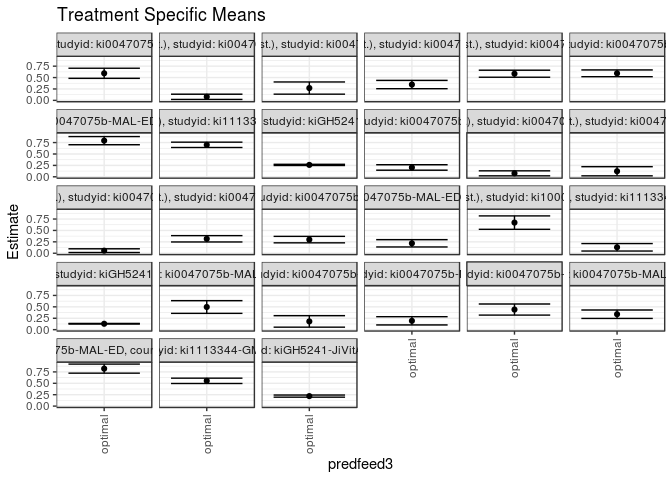

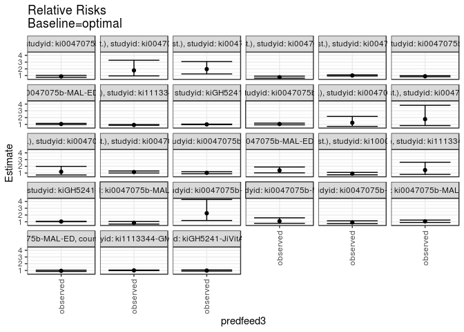

## Results Table

### Parameter: TSM

| agecat | studyid | country | intervention_level | baseline_level | estimate | ci_lower | ci_upper |
| --- | --- | --- | --- | --- | --- | --- | --- |
| 0-24 months (no birth st.) | ki0047075b-MAL-ED | BANGLADESH | optimal | NA | 0.5935778 | 0.4827737 | 0.7043819 |
| 0-24 months (no birth st.) | ki0047075b-MAL-ED | BRAZIL | optimal | NA | 0.0780194 | 0.0208895 | 0.1351493 |
| 0-24 months (no birth st.) | ki0047075b-MAL-ED | INDIA | optimal | NA | 0.2700682 | 0.1363276 | 0.4038088 |
| 0-24 months (no birth st.) | ki0047075b-MAL-ED | NEPAL | optimal | NA | 0.3465245 | 0.2554622 | 0.4375867 |
| 0-24 months (no birth st.) | ki0047075b-MAL-ED | PERU | optimal | NA | 0.5842816 | 0.5072733 | 0.6612899 |
| 0-24 months (no birth st.) | ki0047075b-MAL-ED | SOUTH AFRICA | optimal | NA | 0.5929700 | 0.5189134 | 0.6670266 |
| 0-24 months (no birth st.) | ki0047075b-MAL-ED | TANZANIA, UNITED REPUBLIC OF | optimal | NA | 0.7924724 | 0.7028218 | 0.8821229 |
| 0-24 months (no birth st.) | ki1113344-GMS-Nepal | NEPAL | optimal | NA | 0.7004981 | 0.6421622 | 0.7588340 |
| 0-24 months (no birth st.) | kiGH5241-JiVitA-3 | BANGLADESH | optimal | NA | 0.2608430 | 0.2479081 | 0.2737779 |
| 0-6 months (no birth st.) | ki0047075b-MAL-ED | BANGLADESH | optimal | NA | 0.2047577 | 0.1449253 | 0.2645902 |
| 0-6 months (no birth st.) | ki0047075b-MAL-ED | BRAZIL | optimal | NA | 0.0762932 | 0.0216265 | 0.1309598 |
| 0-6 months (no birth st.) | ki0047075b-MAL-ED | INDIA | optimal | NA | 0.1216606 | 0.0212165 | 0.2221047 |
| 0-6 months (no birth st.) | ki0047075b-MAL-ED | NEPAL | optimal | NA | 0.0563048 | 0.0153811 | 0.0972285 |
| 0-6 months (no birth st.) | ki0047075b-MAL-ED | PERU | optimal | NA | 0.3164755 | 0.2466811 | 0.3862699 |
| 0-6 months (no birth st.) | ki0047075b-MAL-ED | SOUTH AFRICA | optimal | NA | 0.2991470 | 0.2282983 | 0.3699957 |
| 0-6 months (no birth st.) | ki0047075b-MAL-ED | TANZANIA, UNITED REPUBLIC OF | optimal | NA | 0.2174673 | 0.1374335 | 0.2975011 |
| 0-6 months (no birth st.) | ki1000109-EE | PAKISTAN | optimal | NA | 0.6718689 | 0.5249390 | 0.8187987 |
| 0-6 months (no birth st.) | ki1113344-GMS-Nepal | NEPAL | optimal | NA | 0.1301363 | 0.0479575 | 0.2123152 |
| 0-6 months (no birth st.) | kiGH5241-JiVitA-3 | BANGLADESH | optimal | NA | 0.1295236 | 0.1231871 | 0.1358601 |
| 6-24 months | ki0047075b-MAL-ED | BANGLADESH | optimal | NA | 0.4967996 | 0.3577610 | 0.6358383 |
| 6-24 months | ki0047075b-MAL-ED | INDIA | optimal | NA | 0.1809782 | 0.0552363 | 0.3067200 |
| 6-24 months | ki0047075b-MAL-ED | NEPAL | optimal | NA | 0.1938294 | 0.1038184 | 0.2838403 |
| 6-24 months | ki0047075b-MAL-ED | PERU | optimal | NA | 0.4409077 | 0.3193732 | 0.5624423 |
| 6-24 months | ki0047075b-MAL-ED | SOUTH AFRICA | optimal | NA | 0.3386375 | 0.2461801 | 0.4310948 |
| 6-24 months | ki0047075b-MAL-ED | TANZANIA, UNITED REPUBLIC OF | optimal | NA | 0.8211859 | 0.7217449 | 0.9206270 |
| 6-24 months | ki1113344-GMS-Nepal | NEPAL | optimal | NA | 0.5536342 | 0.4952363 | 0.6120322 |
| 6-24 months | kiGH5241-JiVitA-3 | BANGLADESH | optimal | NA | 0.2189489 | 0.1954793 | 0.2424185 |

### Parameter: E(Y)

| agecat | studyid | country | intervention_level | baseline_level | estimate | ci_lower | ci_upper |
| --- | --- | --- | --- | --- | --- | --- | --- |
| 0-24 months (no birth st.) | ki0047075b-MAL-ED | BANGLADESH | observed | NA | 0.5242718 | 0.4559076 | 0.5926361 |
| 0-24 months (no birth st.) | ki0047075b-MAL-ED | BRAZIL | observed | NA | 0.1386139 | 0.0908442 | 0.1863835 |
| 0-24 months (no birth st.) | ki0047075b-MAL-ED | INDIA | observed | NA | 0.5300000 | 0.4606561 | 0.5993439 |
| 0-24 months (no birth st.) | ki0047075b-MAL-ED | NEPAL | observed | NA | 0.2631579 | 0.2033151 | 0.3230007 |
| 0-24 months (no birth st.) | ki0047075b-MAL-ED | PERU | observed | NA | 0.5976096 | 0.5368226 | 0.6583966 |
| 0-24 months (no birth st.) | ki0047075b-MAL-ED | SOUTH AFRICA | observed | NA | 0.5365854 | 0.4741444 | 0.5990263 |
| 0-24 months (no birth st.) | ki0047075b-MAL-ED | TANZANIA, UNITED REPUBLIC OF | observed | NA | 0.8293839 | 0.7785063 | 0.8802614 |
| 0-24 months (no birth st.) | ki1113344-GMS-Nepal | NEPAL | observed | NA | 0.6374408 | 0.5915192 | 0.6833623 |
| 0-24 months (no birth st.) | kiGH5241-JiVitA-3 | BANGLADESH | observed | NA | 0.2580007 | 0.2499160 | 0.2660854 |
| 0-6 months (no birth st.) | ki0047075b-MAL-ED | BANGLADESH | observed | NA | 0.2135922 | 0.1574890 | 0.2696955 |
| 0-6 months (no birth st.) | ki0047075b-MAL-ED | BRAZIL | observed | NA | 0.0940594 | 0.0537041 | 0.1344147 |
| 0-6 months (no birth st.) | ki0047075b-MAL-ED | INDIA | observed | NA | 0.2150000 | 0.1579211 | 0.2720789 |
| 0-6 months (no birth st.) | ki0047075b-MAL-ED | NEPAL | observed | NA | 0.0669856 | 0.0330113 | 0.1009600 |
| 0-6 months (no birth st.) | ki0047075b-MAL-ED | PERU | observed | NA | 0.3625498 | 0.3029582 | 0.4221414 |
| 0-6 months (no birth st.) | ki0047075b-MAL-ED | SOUTH AFRICA | observed | NA | 0.3089431 | 0.2510854 | 0.3668008 |
| 0-6 months (no birth st.) | ki0047075b-MAL-ED | TANZANIA, UNITED REPUBLIC OF | observed | NA | 0.3033175 | 0.2411441 | 0.3654909 |
| 0-6 months (no birth st.) | ki1000109-EE | PAKISTAN | observed | NA | 0.6048387 | 0.5438701 | 0.6658074 |
| 0-6 months (no birth st.) | ki1113344-GMS-Nepal | NEPAL | observed | NA | 0.1872038 | 0.1499427 | 0.2244649 |
| 0-6 months (no birth st.) | kiGH5241-JiVitA-3 | BANGLADESH | observed | NA | 0.1340043 | 0.1282072 | 0.1398014 |
| 6-24 months | ki0047075b-MAL-ED | BANGLADESH | observed | NA | 0.4102564 | 0.3328207 | 0.4876922 |
| 6-24 months | ki0047075b-MAL-ED | INDIA | observed | NA | 0.4090909 | 0.3311846 | 0.4869972 |
| 6-24 months | ki0047075b-MAL-ED | NEPAL | observed | NA | 0.2124352 | 0.1545785 | 0.2702920 |
| 6-24 months | ki0047075b-MAL-ED | PERU | observed | NA | 0.3986486 | 0.3194990 | 0.4777982 |
| 6-24 months | ki0047075b-MAL-ED | SOUTH AFRICA | observed | NA | 0.3589744 | 0.2834562 | 0.4344926 |
| 6-24 months | ki0047075b-MAL-ED | TANZANIA, UNITED REPUBLIC OF | observed | NA | 0.7762238 | 0.7076743 | 0.8447733 |
| 6-24 months | ki1113344-GMS-Nepal | NEPAL | observed | NA | 0.5621302 | 0.5091609 | 0.6150995 |
| 6-24 months | kiGH5241-JiVitA-3 | BANGLADESH | observed | NA | 0.2159269 | 0.2063541 | 0.2254998 |

### Parameter: RR

| agecat | studyid | country | intervention_level | baseline_level | estimate | ci_lower | ci_upper |
| --- | --- | --- | --- | --- | --- | --- | --- |
| 0-24 months (no birth st.) | ki0047075b-MAL-ED | BANGLADESH | observed | optimal | 0.8832403 | 0.7559677 | 1.0319402 |
| 0-24 months (no birth st.) | ki0047075b-MAL-ED | BRAZIL | observed | optimal | 1.7766596 | 0.9619598 | 3.2813424 |
| 0-24 months (no birth st.) | ki0047075b-MAL-ED | INDIA | observed | optimal | 1.9624675 | 1.2473491 | 3.0875709 |
| 0-24 months (no birth st.) | ki0047075b-MAL-ED | NEPAL | observed | optimal | 0.7594208 | 0.6277177 | 0.9187567 |
| 0-24 months (no birth st.) | ki0047075b-MAL-ED | PERU | observed | optimal | 1.0228108 | 0.9398799 | 1.1130592 |
| 0-24 months (no birth st.) | ki0047075b-MAL-ED | SOUTH AFRICA | observed | optimal | 0.9049115 | 0.8290391 | 0.9877277 |
| 0-24 months (no birth st.) | ki0047075b-MAL-ED | TANZANIA, UNITED REPUBLIC OF | observed | optimal | 1.0465777 | 0.9619961 | 1.1385959 |
| 0-24 months (no birth st.) | ki1113344-GMS-Nepal | NEPAL | observed | optimal | 0.9099821 | 0.8540562 | 0.9695702 |
| 0-24 months (no birth st.) | kiGH5241-JiVitA-3 | BANGLADESH | observed | optimal | 0.9891035 | 0.9514415 | 1.0282563 |
| 0-6 months (no birth st.) | ki0047075b-MAL-ED | BANGLADESH | observed | optimal | 1.0431461 | 0.9235847 | 1.1781851 |
| 0-6 months (no birth st.) | ki0047075b-MAL-ED | BRAZIL | observed | optimal | 1.2328679 | 0.6994435 | 2.1731037 |
| 0-6 months (no birth st.) | ki0047075b-MAL-ED | INDIA | observed | optimal | 1.7672117 | 0.8173472 | 3.8209433 |
| 0-6 months (no birth st.) | ki0047075b-MAL-ED | NEPAL | observed | optimal | 1.1896969 | 0.7124018 | 1.9867703 |
| 0-6 months (no birth st.) | ki0047075b-MAL-ED | PERU | observed | optimal | 1.1455856 | 1.0099480 | 1.2994396 |
| 0-6 months (no birth st.) | ki0047075b-MAL-ED | SOUTH AFRICA | observed | optimal | 1.0327469 | 0.8923965 | 1.1951706 |
| 0-6 months (no birth st.) | ki0047075b-MAL-ED | TANZANIA, UNITED REPUBLIC OF | observed | optimal | 1.3947730 | 1.0276248 | 1.8930954 |
| 0-6 months (no birth st.) | ki1000109-EE | PAKISTAN | observed | optimal | 0.9002333 | 0.7375361 | 1.0988207 |
| 0-6 months (no birth st.) | ki1113344-GMS-Nepal | NEPAL | observed | optimal | 1.4385206 | 0.7954936 | 2.6013303 |
| 0-6 months (no birth st.) | kiGH5241-JiVitA-3 | BANGLADESH | observed | optimal | 1.0345937 | 1.0114956 | 1.0582193 |
| 6-24 months | ki0047075b-MAL-ED | BANGLADESH | observed | optimal | 0.8257985 | 0.6555836 | 1.0402078 |
| 6-24 months | ki0047075b-MAL-ED | INDIA | observed | optimal | 2.2604433 | 1.1869970 | 4.3046476 |
| 6-24 months | ki0047075b-MAL-ED | NEPAL | observed | optimal | 1.0959909 | 0.7587870 | 1.5830475 |
| 6-24 months | ki0047075b-MAL-ED | PERU | observed | optimal | 0.9041543 | 0.7205860 | 1.1344865 |
| 6-24 months | ki0047075b-MAL-ED | SOUTH AFRICA | observed | optimal | 1.0600550 | 0.8974121 | 1.2521746 |
| 6-24 months | ki0047075b-MAL-ED | TANZANIA, UNITED REPUBLIC OF | observed | optimal | 0.9452473 | 0.8548830 | 1.0451634 |
| 6-24 months | ki1113344-GMS-Nepal | NEPAL | observed | optimal | 1.0153458 | 0.9722732 | 1.0603266 |
| 6-24 months | kiGH5241-JiVitA-3 | BANGLADESH | observed | optimal | 0.9861979 | 0.8965765 | 1.0847777 |

### Parameter: PAR

| agecat | studyid | country | intervention_level | baseline_level | estimate | ci_lower | ci_upper |
| --- | --- | --- | --- | --- | --- | --- | --- |
| 0-24 months (no birth st.) | ki0047075b-MAL-ED | BANGLADESH | optimal | NA | -0.0693060 | -0.1606845 | 0.0220726 |
| 0-24 months (no birth st.) | ki0047075b-MAL-ED | BRAZIL | optimal | NA | 0.0605945 | 0.0102625 | 0.1109264 |
| 0-24 months (no birth st.) | ki0047075b-MAL-ED | INDIA | optimal | NA | 0.2599318 | 0.1393519 | 0.3805118 |
| 0-24 months (no birth st.) | ki0047075b-MAL-ED | NEPAL | optimal | NA | -0.0833666 | -0.1479313 | -0.0188019 |
| 0-24 months (no birth st.) | ki0047075b-MAL-ED | PERU | optimal | NA | 0.0133279 | -0.0361061 | 0.0627619 |
| 0-24 months (no birth st.) | ki0047075b-MAL-ED | SOUTH AFRICA | optimal | NA | -0.0563846 | -0.1068995 | -0.0058697 |
| 0-24 months (no birth st.) | ki0047075b-MAL-ED | TANZANIA, UNITED REPUBLIC OF | optimal | NA | 0.0369115 | -0.0294843 | 0.1033073 |
| 0-24 months (no birth st.) | ki1113344-GMS-Nepal | NEPAL | optimal | NA | -0.0630574 | -0.1065792 | -0.0195355 |
| 0-24 months (no birth st.) | kiGH5241-JiVitA-3 | BANGLADESH | optimal | NA | -0.0028423 | -0.0129677 | 0.0072831 |
| 0-6 months (no birth st.) | ki0047075b-MAL-ED | BANGLADESH | optimal | NA | 0.0088345 | -0.0161423 | 0.0338113 |
| 0-6 months (no birth st.) | ki0047075b-MAL-ED | BRAZIL | optimal | NA | 0.0177662 | -0.0260197 | 0.0615522 |
| 0-6 months (no birth st.) | ki0047075b-MAL-ED | INDIA | optimal | NA | 0.0933394 | -0.0027159 | 0.1893947 |
| 0-6 months (no birth st.) | ki0047075b-MAL-ED | NEPAL | optimal | NA | 0.0106808 | -0.0186141 | 0.0399758 |
| 0-6 months (no birth st.) | ki0047075b-MAL-ED | PERU | optimal | NA | 0.0460743 | 0.0065245 | 0.0856241 |
| 0-6 months (no birth st.) | ki0047075b-MAL-ED | SOUTH AFRICA | optimal | NA | 0.0097961 | -0.0339484 | 0.0535407 |
| 0-6 months (no birth st.) | ki0047075b-MAL-ED | TANZANIA, UNITED REPUBLIC OF | optimal | NA | 0.0858502 | 0.0171416 | 0.1545589 |
| 0-6 months (no birth st.) | ki1000109-EE | PAKISTAN | optimal | NA | -0.0670301 | -0.2007816 | 0.0667213 |
| 0-6 months (no birth st.) | ki1113344-GMS-Nepal | NEPAL | optimal | NA | 0.0570675 | -0.0204666 | 0.1346015 |
| 0-6 months (no birth st.) | kiGH5241-JiVitA-3 | BANGLADESH | optimal | NA | 0.0044807 | 0.0015510 | 0.0074104 |
| 6-24 months | ki0047075b-MAL-ED | BANGLADESH | optimal | NA | -0.0865432 | -0.2003941 | 0.0273076 |
| 6-24 months | ki0047075b-MAL-ED | INDIA | optimal | NA | 0.2281127 | 0.1090586 | 0.3471669 |
| 6-24 months | ki0047075b-MAL-ED | NEPAL | optimal | NA | 0.0186058 | -0.0526851 | 0.0898968 |
| 6-24 months | ki0047075b-MAL-ED | PERU | optimal | NA | -0.0422591 | -0.1412720 | 0.0567538 |
| 6-24 months | ki0047075b-MAL-ED | SOUTH AFRICA | optimal | NA | 0.0203369 | -0.0360738 | 0.0767475 |
| 6-24 months | ki0047075b-MAL-ED | TANZANIA, UNITED REPUBLIC OF | optimal | NA | -0.0449622 | -0.1268466 | 0.0369223 |
| 6-24 months | ki1113344-GMS-Nepal | NEPAL | optimal | NA | 0.0084960 | -0.0154801 | 0.0324720 |
| 6-24 months | kiGH5241-JiVitA-3 | BANGLADESH | optimal | NA | -0.0030220 | -0.0238895 | 0.0178456 |

### Parameter: PAF

| agecat | studyid | country | intervention_level | baseline_level | estimate | ci_lower | ci_upper |
| --- | --- | --- | --- | --- | --- | --- | --- |
| 0-24 months (no birth st.) | ki0047075b-MAL-ED | BANGLADESH | optimal | NA | -0.1321947 | -0.3228078 | 0.0309516 |
| 0-24 months (no birth st.) | ki0047075b-MAL-ED | BRAZIL | optimal | NA | 0.4371460 | -0.0395445 | 0.6952467 |
| 0-24 months (no birth st.) | ki0047075b-MAL-ED | INDIA | optimal | NA | 0.4904374 | 0.1982998 | 0.6761208 |
| 0-24 months (no birth st.) | ki0047075b-MAL-ED | NEPAL | optimal | NA | -0.3167931 | -0.5930727 | -0.0884274 |
| 0-24 months (no birth st.) | ki0047075b-MAL-ED | PERU | optimal | NA | 0.0223021 | -0.0639658 | 0.1015752 |
| 0-24 months (no birth st.) | ki0047075b-MAL-ED | SOUTH AFRICA | optimal | NA | -0.1050804 | -0.2062157 | -0.0124248 |
| 0-24 months (no birth st.) | ki0047075b-MAL-ED | TANZANIA, UNITED REPUBLIC OF | optimal | NA | 0.0445047 | -0.0395053 | 0.1217253 |
| 0-24 months (no birth st.) | ki1113344-GMS-Nepal | NEPAL | optimal | NA | -0.0989227 | -0.1708831 | -0.0313849 |
| 0-24 months (no birth st.) | kiGH5241-JiVitA-3 | BANGLADESH | optimal | NA | -0.0110166 | -0.0510368 | 0.0274798 |
| 0-6 months (no birth st.) | ki0047075b-MAL-ED | BANGLADESH | optimal | NA | 0.0413615 | -0.0827378 | 0.1512370 |
| 0-6 months (no birth st.) | ki0047075b-MAL-ED | BRAZIL | optimal | NA | 0.1888831 | -0.4297081 | 0.5398287 |
| 0-6 months (no birth st.) | ki0047075b-MAL-ED | INDIA | optimal | NA | 0.4341368 | -0.2234703 | 0.7382845 |
| 0-6 months (no birth st.) | ki0047075b-MAL-ED | NEPAL | optimal | NA | 0.1594498 | -0.4037023 | 0.4966706 |
| 0-6 months (no birth st.) | ki0047075b-MAL-ED | PERU | optimal | NA | 0.1270840 | 0.0098500 | 0.2304375 |
| 0-6 months (no birth st.) | ki0047075b-MAL-ED | SOUTH AFRICA | optimal | NA | 0.0317085 | -0.1205781 | 0.1632994 |
| 0-6 months (no birth st.) | ki0047075b-MAL-ED | TANZANIA, UNITED REPUBLIC OF | optimal | NA | 0.2830375 | 0.0268822 | 0.4717646 |
| 0-6 months (no birth st.) | ki1000109-EE | PAKISTAN | optimal | NA | -0.1108232 | -0.3558657 | 0.0899334 |
| 0-6 months (no birth st.) | ki1113344-GMS-Nepal | NEPAL | optimal | NA | 0.3048414 | -0.2570812 | 0.6155813 |
| 0-6 months (no birth st.) | kiGH5241-JiVitA-3 | BANGLADESH | optimal | NA | 0.0334370 | 0.0113649 | 0.0550163 |
| 6-24 months | ki0047075b-MAL-ED | BANGLADESH | optimal | NA | -0.2109491 | -0.5253584 | 0.0386536 |
| 6-24 months | ki0047075b-MAL-ED | INDIA | optimal | NA | 0.5576089 | 0.1575379 | 0.7676929 |
| 6-24 months | ki0047075b-MAL-ED | NEPAL | optimal | NA | 0.0875836 | -0.3178928 | 0.3683070 |
| 6-24 months | ki0047075b-MAL-ED | PERU | optimal | NA | -0.1060059 | -0.3877594 | 0.1185439 |
| 6-24 months | ki0047075b-MAL-ED | SOUTH AFRICA | optimal | NA | 0.0566527 | -0.1143153 | 0.2013893 |
| 6-24 months | ki0047075b-MAL-ED | TANZANIA, UNITED REPUBLIC OF | optimal | NA | -0.0579242 | -0.1697507 | 0.0432118 |
| 6-24 months | ki1113344-GMS-Nepal | NEPAL | optimal | NA | 0.0151139 | -0.0285175 | 0.0568943 |
| 6-24 months | kiGH5241-JiVitA-3 | BANGLADESH | optimal | NA | -0.0139953 | -0.1153538 | 0.0781522 |